# E - Intmap Analyse

Kann neue Verzweigung auslösen

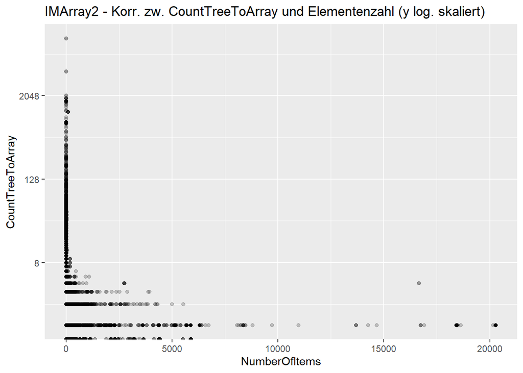

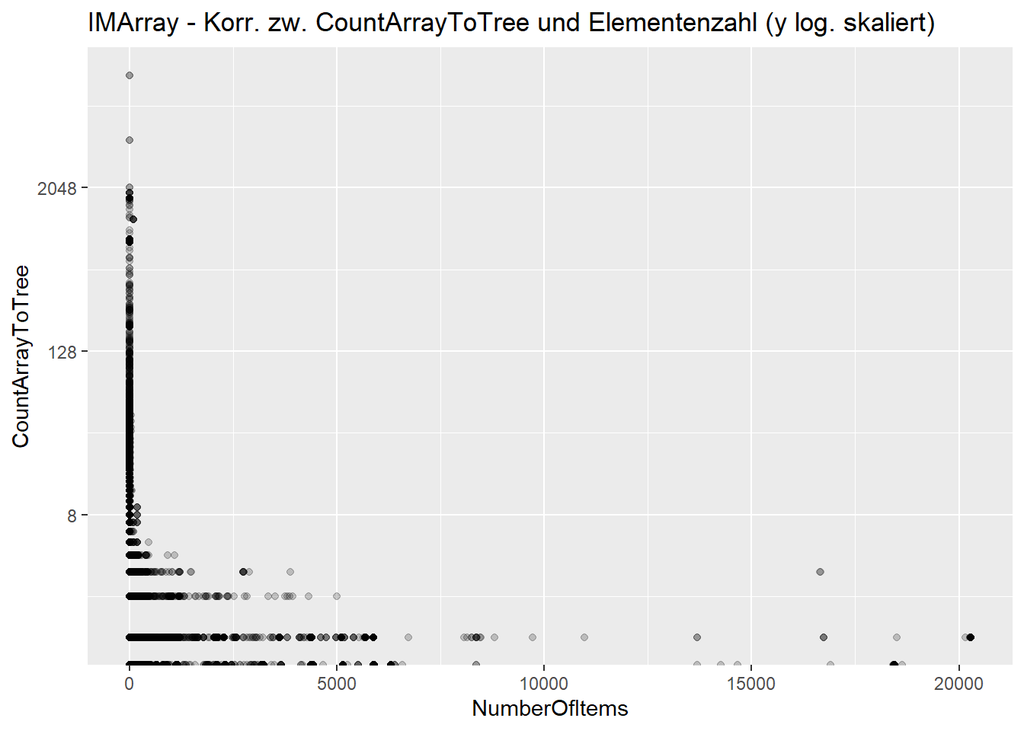

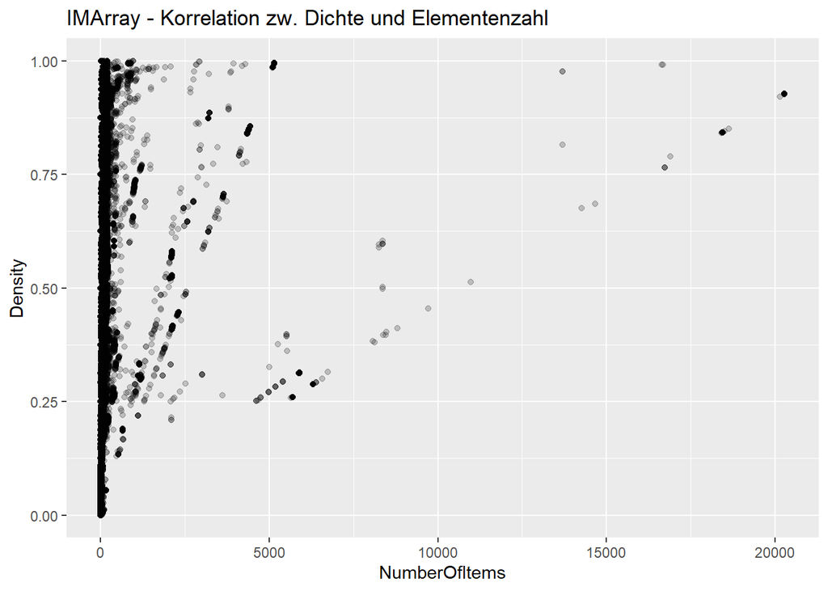

#### IMTree

```
##     EntryNo             MinKey             MaxKey        CountGetVal
##  Min.   :   1.000   Min.   :    -1.0   Min.   :    -1   Min.   :       0
##  1st Qu.:   3.000   1st Qu.:    -1.0   1st Qu.:    91   1st Qu.:       0
##  Median :   4.000   Median :    26.0   Median :   410   Median :       8
##  Mean   :   6.679   Mean   :   284.4   Mean   :  1983   Mean   :    2788
##  3rd Qu.:   7.000   3rd Qu.:    74.0   3rd Qu.:  2262   3rd Qu.:      67
##  Max.   :5875.000   Max.   :195436.0   Max.   :358741   Max.   :24478141
##   CountGetRef       CountAssign        CountDelKey       CountArrayToTree
##  Min.   :      2   Min.   :0.00e+00   Min.   :   0.000   Min.   :   0.0000
##  1st Qu.:      4   1st Qu.:0.00e+00   1st Qu.:   0.000   1st Qu.:   0.0000
##  Median :      8   Median :0.00e+00   Median :   0.000   Median :   1.0000
##  Mean   :    125   Mean   :5.13e-03   Mean   :   0.485   Mean   :   0.6255
##  3rd Qu.:     23   3rd Qu.:0.00e+00   3rd Qu.:   0.000   3rd Qu.:   1.0000
##  Max.   :2174745   Max.   :3.01e+02   Max.   :8658.000   Max.   :1638.0000
##  CountTreeToArray    NumberOfItems        TreeHeight          MinNode
##  Min.   :   0.0000   Min.   :   1.000   Min.   :   1.000   Min.   :    -1.0
##  1st Qu.:   0.0000   1st Qu.:   3.000   1st Qu.:   2.000   1st Qu.:    -1.0
##  Median :   0.0000   Median :   4.000   Median :   4.000   Median :    27.0
##  Mean   :   0.0196   Mean   :   6.679   Mean   :   4.546   Mean   :   291.1
##  3rd Qu.:   0.0000   3rd Qu.:   7.000   3rd Qu.:   5.000   3rd Qu.:    80.0
##  Max.   :1637.0000   Max.   :5875.000   Max.   :4348.000   Max.   :213230.0
##     MaxNode       MinMaxDistance     Linearity          Density
##  Min.   :    -1   Min.   :     0   Min.   :  1.000   Min.   :0.0000056
##  1st Qu.:    91   1st Qu.:    65   1st Qu.:  1.000   1st Qu.:0.0037369
##  Median :   410   Median :   217   Median :  1.000   Median :0.0215054
##  Mean   :  1983   Mean   :  1692   Mean   :  1.263   Mean   :0.0544111
##  3rd Qu.:  2262   3rd Qu.:  1381   3rd Qu.:  1.333   3rd Qu.:0.0653595
##  Max.   :358741   Max.   :358742   Max.   :153.964   Max.   :1.0000000
```

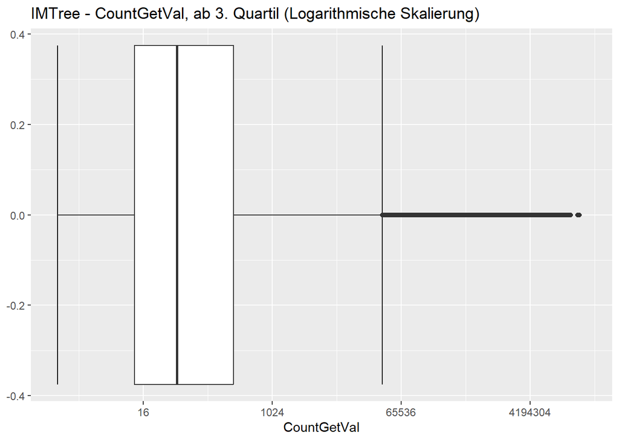

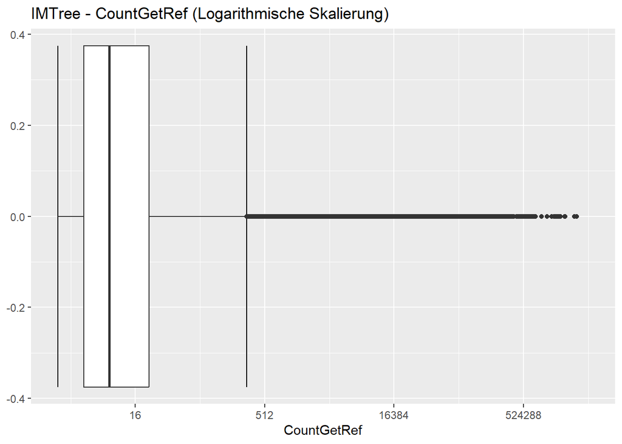

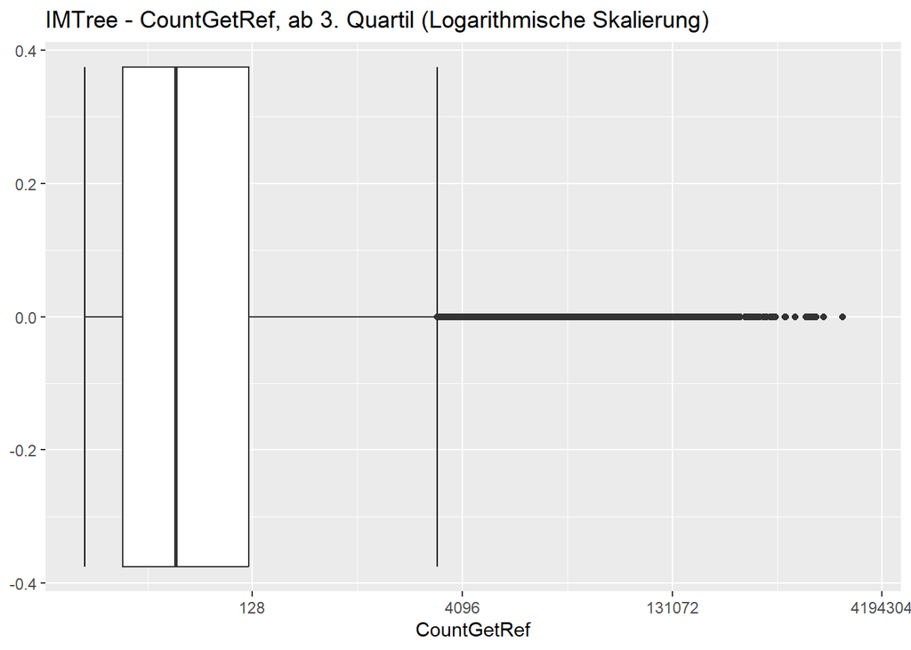

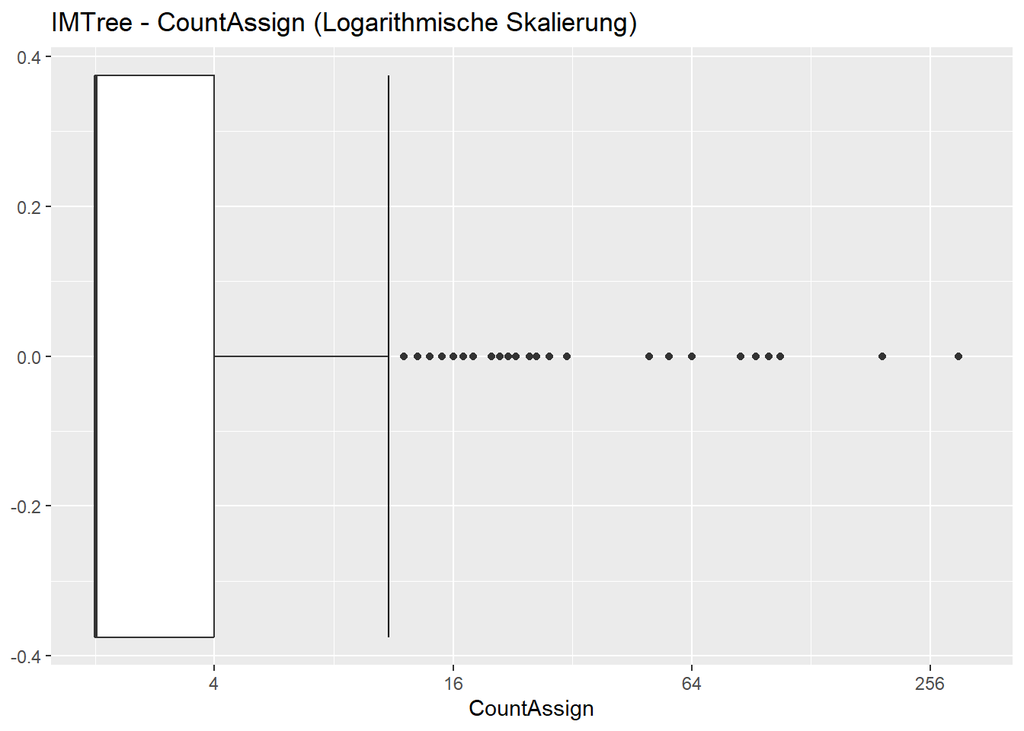

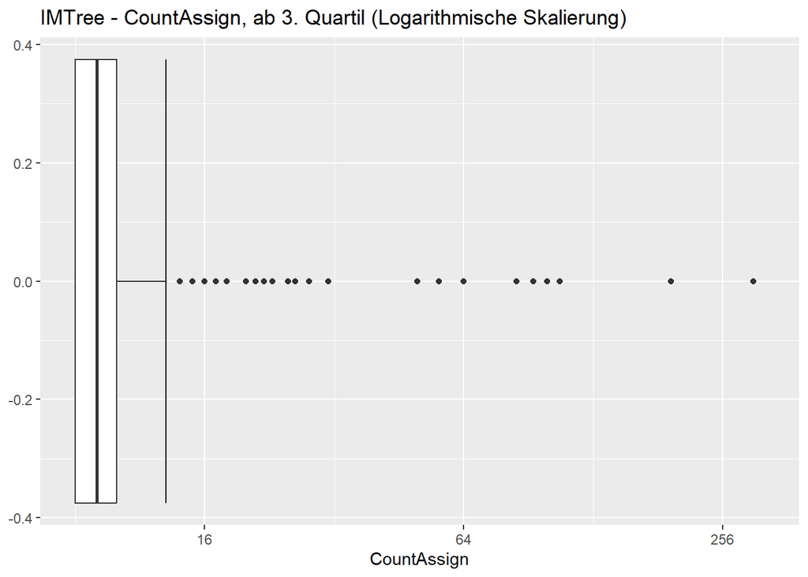

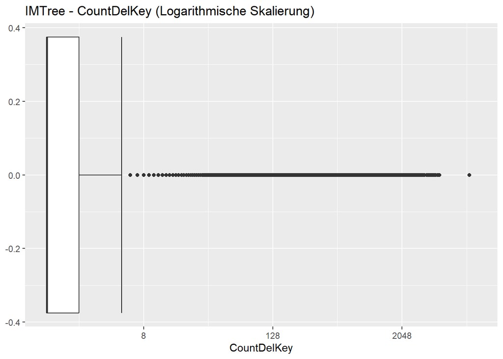

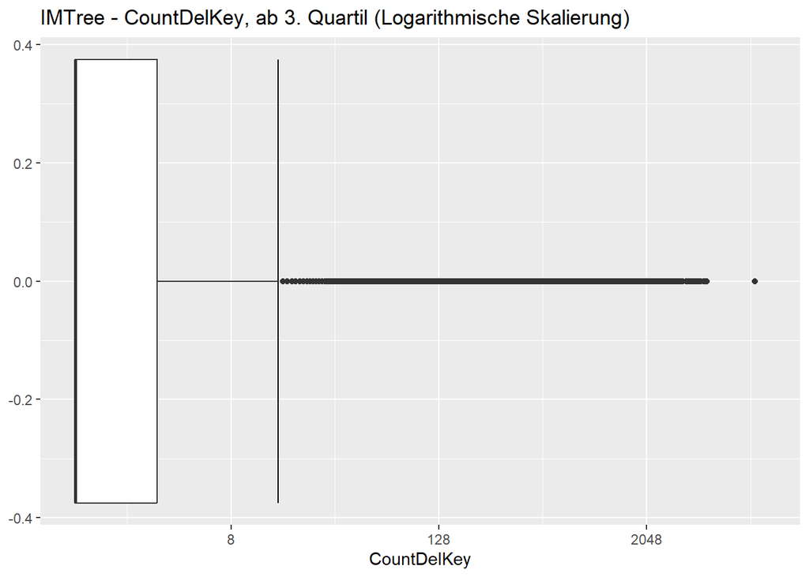

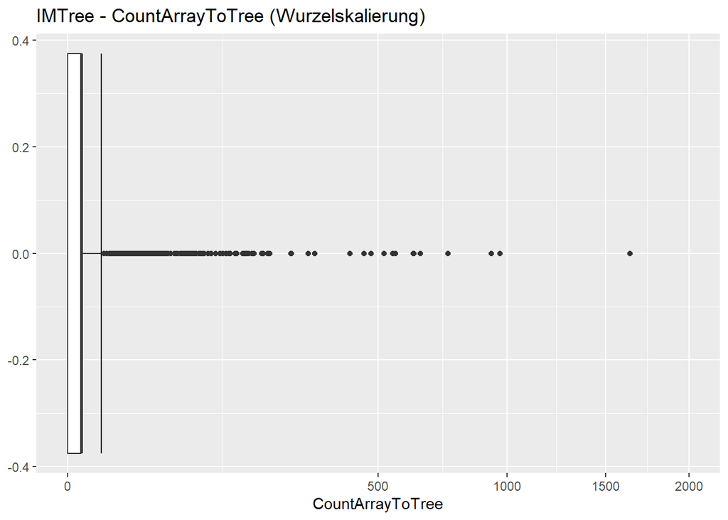

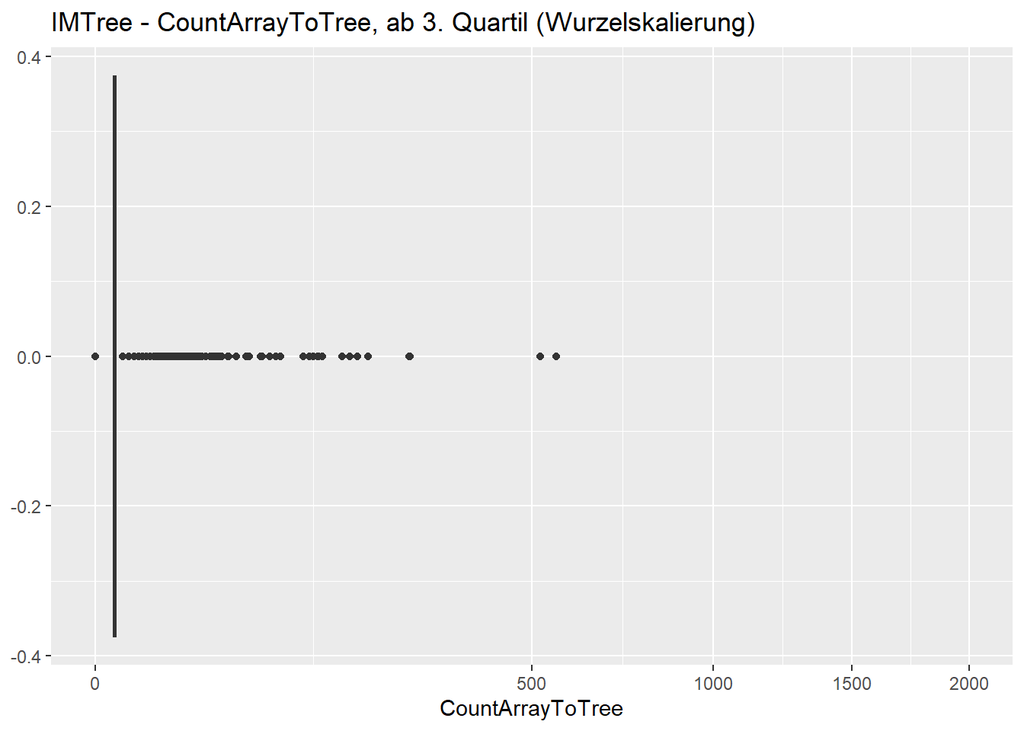

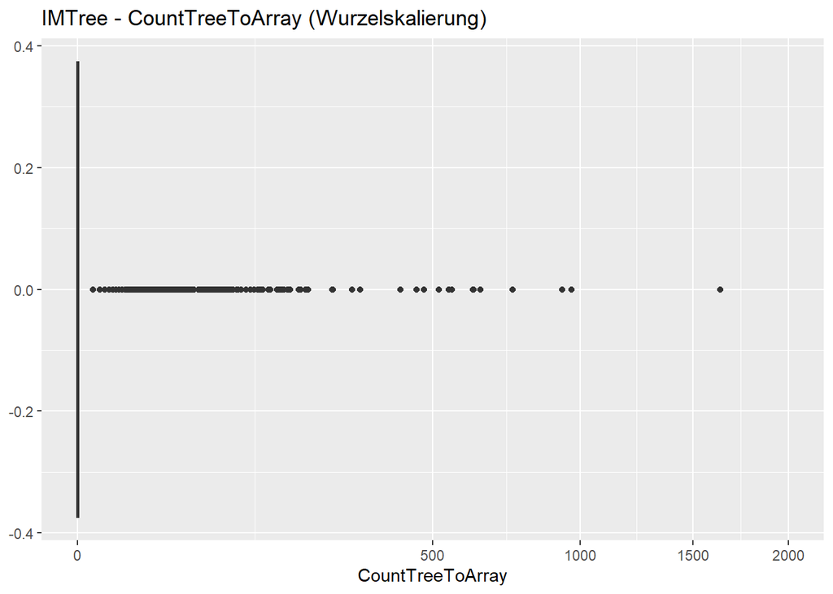

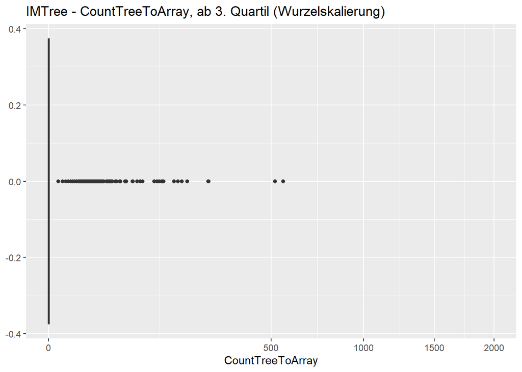

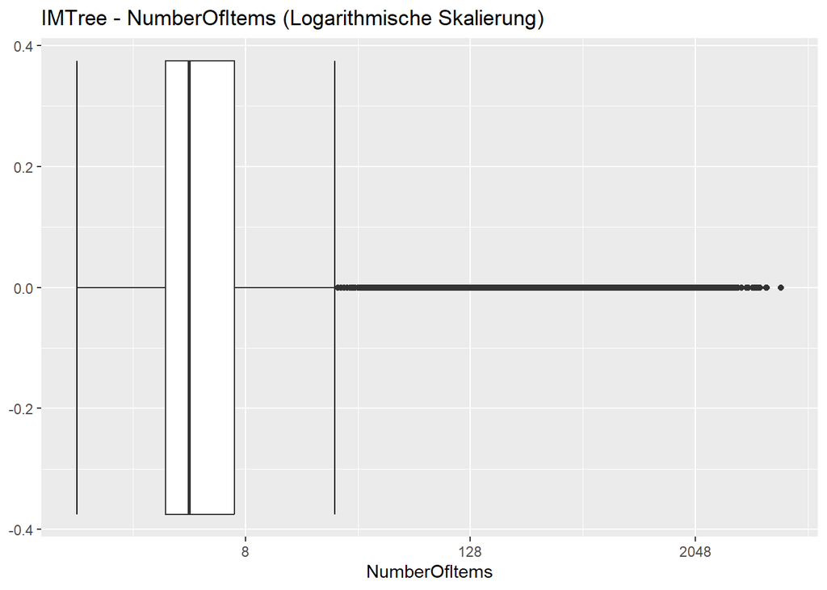

[5 more figures not shown]

Einie Ausreißer nach 50 (Größter bei 155) - der Großteil der Ausreißer liegt unter dem Wert 50.

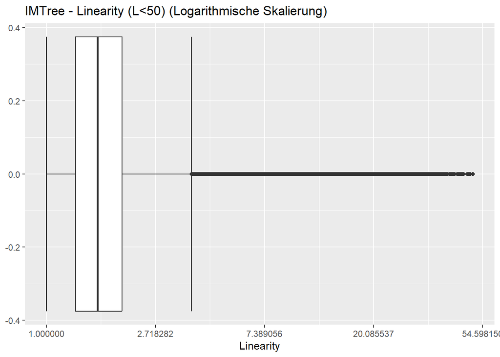

Verteilung: Zu sehen ist, dass die Linearität meist zwischen 1 und 2 ist

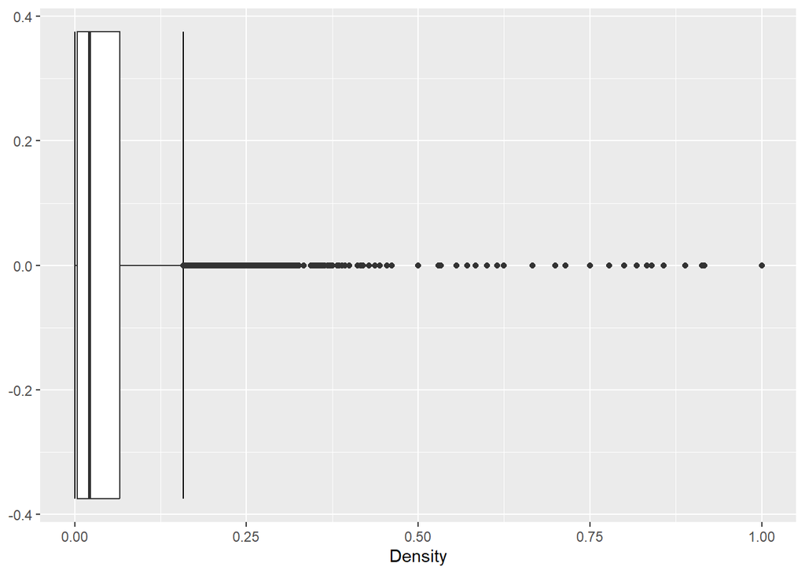

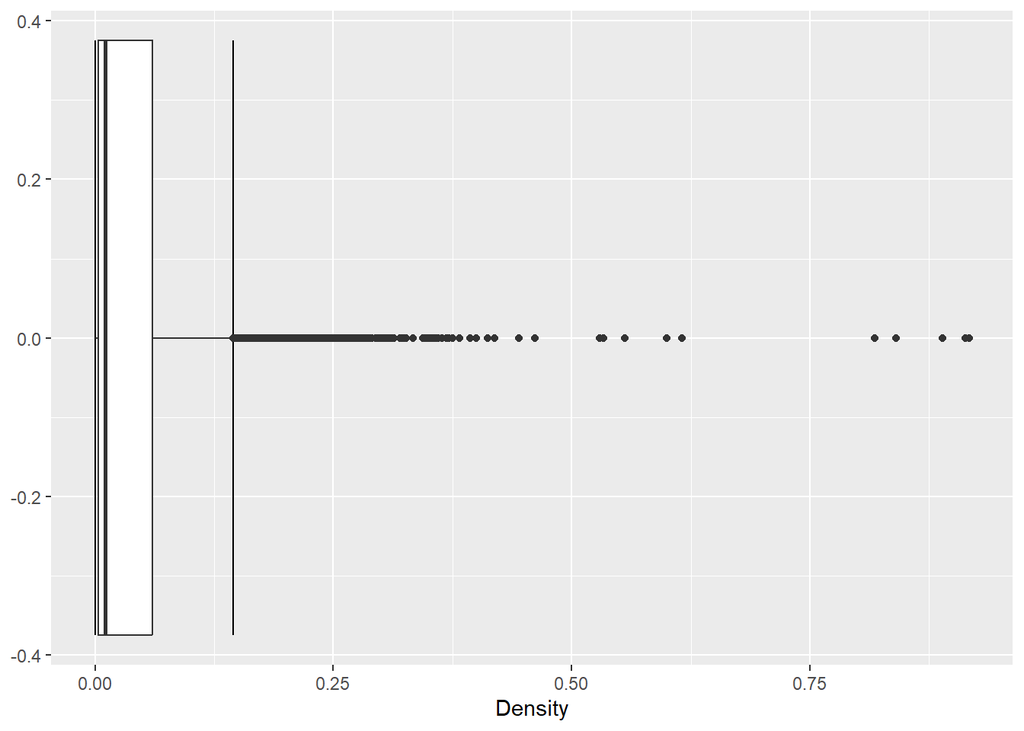

Dichte für Bäume mit mehr als 7 Knoten: Bei weniger gibt es Verzerrung, denn meist sind diese voll besetzt. Von Interesse sind vor allem größere Bäume.

Dichte für Bäume liegt meist unter 0,125 und davon mehr als die Hälfte unter 0,02. Damit sind sie sehr dünn besiedelt. Aufgrund des höheren Speicheraufwandes so gewollt. (Dichte für Bäume und Arrays)

Dichte ist geringer als bei Arrays

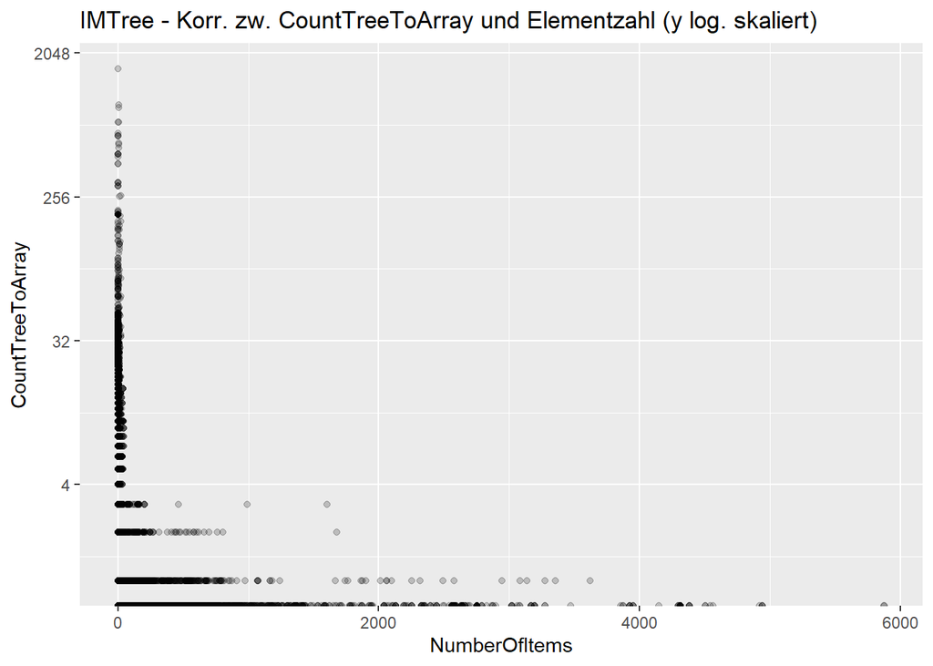

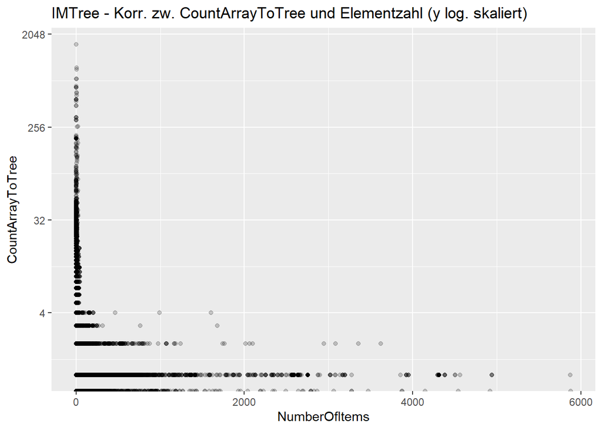

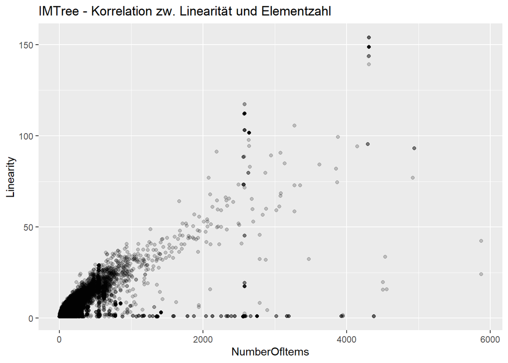

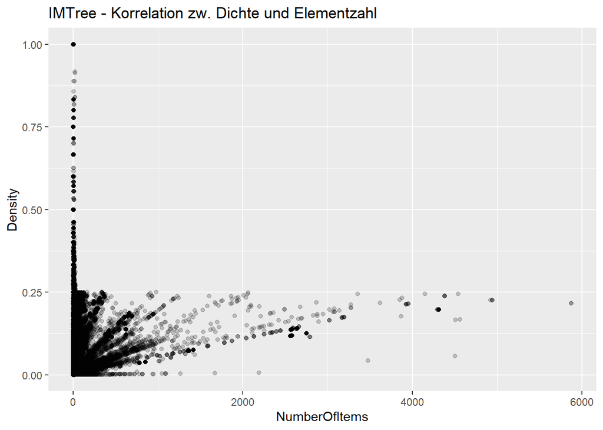

Fazit Im Allgemeinen lässt sich sagen, dass für ein Problem meist recht kleine Intmaps angelegt werden, dafür aber sehr viele. Filtern nach Dauer der Probleme

Korrelation zwischen GetRef - Items

Success - warum keine Ausgabe?

Dichte Für Array gut bei Median 0.25 Dichte Für Baum Diche muss größer sein als beim Array

Anzahl Knote / MinMax = Dichte

Korrelation zwischen Größe - Linearität

20.03